```python
NAME = "Suprya Azhakath"
```

# Logistic Regression in Python

In this part of the homework, we'll briefly train some logistic regression models in Python, using functions available through scikit-learn.

HW adopted partially from Hands-On Machine Learning with Scikit-Learn, Keras, & TensorFlow by Aurelien Geron, and the scikit-learn documentation: https://scikit-learn.org/stable/modules/generated/sklearn.linear_model.LogisticRegression.html.

Run the following cell to import some of our basic libraries/objects, including inlucing the `LogisticRegression` model from `sklearn.linear_model`.

```python
import numpy as np
import matplotlib.pyplot as plt
import pandas as pd


#confusion_matrix and accuracy_score may come in handy
from sklearn.metrics import confusion_matrix
from sklearn.metrics import accuracy_score

#Various helper functions
from sklearn.model_selection import train_test_split
from sklearn.pipeline import make_pipeline
from sklearn.preprocessing import StandardScaler
from sklearn.preprocessing import PolynomialFeatures

#Logistic Regression
from sklearn.linear_model import LogisticRegression
```

## Iris Data

Let's get the iris dataset: This dataset contains sepal and petal length and width for 150 iris flowers of species *Iris setosa*, *Iris versicolor*, and *Iris virginica*. Luckily, we can just load as follows:

```python
from sklearn import datasets

iris = datasets.load_iris()

#We got?
iris
```

[output not shown]

[output cut: 111 more lines]

[output not shown]

Let's put this into a dataframe:

```python
#Create initial DataFrame:
df = pd.DataFrame(np.concatenate((iris['data'], iris['target'].reshape(-1,1)), axis=1),
                  columns = list(iris['feature_names']) + ['species'])

df['species'] = df['species'].astype(int)
df.head()
```

|  | sepal length (cm) | sepal width (cm) | petal length (cm) | petal width (cm) | species |
| --- | --- | --- | --- | --- | --- |
| 0 | 5.1 | 3.5 | 1.4 | 0.2 | 0 |
| 1 | 4.9 | 3.0 | 1.4 | 0.2 | 0 |
| 2 | 4.7 | 3.2 | 1.3 | 0.2 | 0 |
| 3 | 4.6 | 3.1 | 1.5 | 0.2 | 0 |
| 4 | 5.0 | 3.6 | 1.4 | 0.2 | 0 |

And add in the species names:

```python
#Add species name for our reference
#####

df['name'] = [iris['target_names'][i] for i in df.species.astype(int)]

df.head()
```

|  | sepal length (cm) | sepal width (cm) | petal length (cm) | petal width (cm) | species | name |
| --- | --- | --- | --- | --- | --- | --- |
| 0 | 5.1 | 3.5 | 1.4 | 0.2 | 0 | setosa |
| 1 | 4.9 | 3.0 | 1.4 | 0.2 | 0 | setosa |
| 2 | 4.7 | 3.2 | 1.3 | 0.2 | 0 | setosa |
| 3 | 4.6 | 3.1 | 1.5 | 0.2 | 0 | setosa |
| 4 | 5.0 | 3.6 | 1.4 | 0.2 | 0 | setosa |

## Train/Test Split

Now, let's use our four iris measurements, `sepal length (cm)`, `sepal width (cm)`, `petal length (cm)`, `petal width (cm)` (in that order!), as input/predictors, and `species` (as an integer) as output.

Create the DataFrames `X` and Series `y` from our predictor and output variables, respectively.

Then split these into training and testing datasets using the `train_test_split` function, with **50%** of our data reserved for testing. **Use `random_state = 1234` for reproducibility.**

Name your resulting training/testing datasets `X_train`, `X_test`, `y_train`, and `y_test`.

```python
#DF X
from sklearn import datasets
import pandas as pd
from sklearn.model_selection import train_test_split

#iris dataset
iris = datasets.load_iris()

#predictor variables
X = pd.DataFrame(iris['data'], columns=iris['feature_names'])

#output variable
y = pd.Series(iris['target'])

#Split datasets into training and testing datasets. X_train, X_test, y_train, and y_test will be used for training and testing.
X_train, X_test, y_train, y_test = train_test_split(X, y, test_size=0.5, random_state=1234)
```

```python
## test whether the first 2 rows of X_train are correct:
c = np.array([[7.9, 3.8, 6.4, 2.0],
       [5.7, 4.4, 1.5, 0.4]])

assert np.isclose(X_train.iloc[:2,:].values, c).sum() == 8

## test whether the first 4 rows of y_train are correct:
assert np.isclose(y_train[:4].values, np.array([2, 0, 1, 1])).sum() == 4


c = np.array([[6.1, 3.0, 4.6, 1.4],
       [6.1, 2.9, 4.7, 1.4]])

## test whether the first 2 rows of X_test are correct:
assert np.isclose(X_test.iloc[:2,:].values, c).sum() == 8

## test whether the first 4 rows of y_test are correct:
assert np.isclose(y_test[:4].values, np.array([1, 1, 2, 0])).sum() == 4
```

## Single Predictor, Binary Output

Let's just use `petal width (cm)` to predict whether a flower is or is not species `Iris versicolor`.

Create new training and testing **DataFrames** `X_train_pw` and `X_test_pw`, and **Series** `y_train_versicolor` and `y_test_versicolor`, where the latter are `1` if a flower is of species *Iris versicolor*, and `0` otherwise.

```python
#petal width (cm) is spit for training and testing sets
X_train_pw = X_train[['petal width (cm)']]
X_test_pw = X_test[['petal width (cm)']]

# binary outcomes for flower is Iris versicolor or Is not?
y_train_versicolor = y_train.apply(lambda x: 1 if x == 1 else 0)
y_test_versicolor = y_test.apply(lambda x: 1 if x == 1 else 0)
```

```python
## test whether the first 5 rows of X_train_pw are correct:
assert np.isclose(X_train_pw[:5].values.reshape(1,-1), np.array([2, .4, 1.5, 1.3, .4])).sum() == 5

## test whether the first 5 rows of y_train_setosa are correct:
assert np.isclose(y_train_versicolor[:5].values, np.array([0, 0, 1, 1, 0])).sum() == 5


## test whether the first 5 rows of X_test_pw are correct:
assert np.isclose(X_test_pw[:5].values.reshape(1,-1), np.array([1.4, 1.4, 1.8, .3, 1.4])).sum() == 5

## test whether the first 5 rows of y_test_setosa are correct:
assert np.isclose(y_test_versicolor[:5].values, np.array([1, 1, 0, 0, 1])).sum() == 5
```

## Make a Pipeline for Adding Polynomial Features, Rescaling

Construct a pipeline named `lr_model` using the `make_pipeline` function from Scikit-Learn that does the following in sequence:

1. `PolynomialFeatures()` of degree 3
2. Applies `StandardScaler()`
3. Perform `LogisticRegression()`

Then, *fit* `lr_model` the training data `X_train_pw` with target `y_train_versicolor`.

Note that the Scikit-Learn `LogisticRegression` class uses L2 regularization by default. Simply use the defaults with respect to regularization.

```python
from sklearn.pipeline import make_pipeline
from sklearn.preprocessing import PolynomialFeatures, StandardScaler
from sklearn.linear_model import LogisticRegression

#pipeline
lr_model = make_pipeline(
    PolynomialFeatures(degree=3),
    StandardScaler(),
    LogisticRegression()
)

#fiting the modle
lr_model.fit(X_train_pw, y_train_versicolor)
```

```
Pipeline(steps=[('polynomialfeatures', PolynomialFeatures(degree=3)),
                ('standardscaler', StandardScaler()),
                ('logisticregression', LogisticRegression())])
```

```python
##Check whether steps for lr_model are correct

assert isinstance(lr_model.steps[0][1], PolynomialFeatures)

assert isinstance(lr_model.steps[1][1], StandardScaler)

assert isinstance(lr_model.steps[2][1], LogisticRegression)
```

## Make Predictions on Testing Data

Having fit the model/pipeline, make predictions on the testing data, `X_test_pw`. Assign your predictions to the variable `yhat_versicolor`.

```python
# your code here
#predictions on the testing data, trying to match assert
yhat_versicolor = lr_model.predict(X_test_pw)
print(yhat_versicolor)
```

```
[1 1 0 0 1 0 0 0 1 0 1 0 0 1 0 1 0 0 0 1 1 1 1 1 0 0 0 1 0 0 1 0 0 1 0 0 0
 0 0 1 0 1 0 0 0 0 0 0 0 0 0 0 0 1 1 1 1 1 1 0 0 0 0 0 0 0 0 0 1 1 0 1 0 0
 0]
```

```python
## test whether the first 10 elements of yhat_versicolor are correct:
assert np.isclose(yhat_versicolor[:10], np.array([1, 1, 0, 0, 1, 0, 0, 0, 1, 0])).sum() == 10
```

## Graphically Characterize Results

Reproduce (in essence) the following figure that visually depicts the testing observations along with the model-predicted probability that an instace belongs or does not belong to the Iris versicolor class, based on petal width.

[figure not shown]

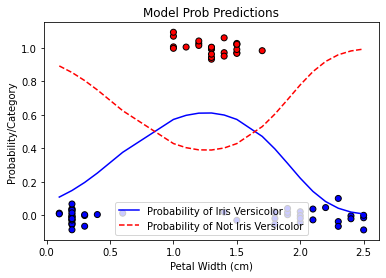

```python
#predict prob for the test set
probabilities = lr_model.predict_proba(X_test_pw)

#Extract prob of being Iris versicolor (class 1)
versicolor_probs = probabilities[:, 1]

#Petal widths from the test set for plotting flattened array
petal_widths = X_test_pw.values.flatten()

#Sorting widths and probs for line plot
sorted_indices = np.argsort(petal_widths)
sorted_petal_widths = petal_widths[sorted_indices]
sorted_versicolor_probs = versicolor_probs[sorted_indices]

#Plotting prob of Iris
plt.plot(sorted_petal_widths, sorted_versicolor_probs, color='blue', label='Probability of Iris Versicolor')

#Plotting prob of not being Iris
plt.plot(sorted_petal_widths, 1 - sorted_versicolor_probs, color='red', linestyle='--', label='Probability of Not Iris Versicolor')

#Iris versicolor (1) and not Iris versicolor (0)
actual_versicolor = y_test_versicolor.values

random_offsets = np.random.normal(0, 0.04, size=len(actual_versicolor))

# Scatter plot for actual test observations with adjusted offsets
plt.scatter(petal_widths, actual_versicolor + random_offsets, c=actual_versicolor, cmap='bwr', edgecolors='k')

plt.xlabel('Petal Width (cm)')
plt.ylabel('Probability/Category')
plt.title('Model Prob Predictions')
plt.legend()
plt.show()
```

### Classifier Metrics

Using your predictions on the *test* data, report the following metrics assigned to the following variables:

1. `precision` = Precision (positive predictive value)
2. `recall` = Recall (sensitivity, true positive rate)
3. `F1` = F1 Score (Harmonic mean of recall and precision)
4. `acc` = Accuracy

```python
from sklearn.metrics import precision_score, recall_score, f1_score, accuracy_score

#pred test data
y_pred = lr_model.predict(X_test_pw)

#metrics
precision = precision_score(y_test_versicolor, y_pred)
recall = recall_score(y_test_versicolor, y_pred)
f1 = f1_score(y_test_versicolor, y_pred)  # F1 is correctly assigned here
acc = accuracy_score(y_test_versicolor, y_pred)

print(f"Precision: {precision}")
print(f"Recall: {recall}")
print(f"F1 Score: {f1}")
print(f"Accuracy: {acc}")
```

```
Precision: 0.9230769230769231
Recall: 0.96
F1 Score: 0.9411764705882353
Accuracy: 0.96
```

```python
## test whether the 2nd and 3rd decimal digits of precision are 23
assert np.mod(int(np.floor(precision * 10**3)), 100) == 23

## test whether the 2nd and 3rd decimal digits of recall are 60
assert np.mod(int(np.floor(recall * 10**3)), 100) == 60

## test whether the 2nd and 3rd decimal digits of f1 are 41
assert np.mod(int(np.floor(f1 * 10**3)), 100) == 41

## test whether the 2nd and 3rd decimal digits of acc are 60
assert np.mod(int(np.floor(acc * 10**3)), 100) == 60
```

```python
## test whether precision, recall, f1, and acc are correct (hidden tests)
```

## Logistic Regression (i.e., Multinomial Regression) for All Species

Basic logistic regression cannot be used in a classification problem with more than 2 classes. However, we can create an ensemble of one-vs-rest logistic models for a multi-class problem.

We can also perform multinomial logistic regression (this is assured simply by setting the parameter `multi_class = "multinomial"` when we create the logistic regression model).

#### Re-fit and Predict

Re-fit the `lr_model` model using petal width as the only predictor, but with all three classes of Iris included in the output (target).

Predict the Iris class on the *testing* data (just petal width), and assign the result to `yhat_all`.

```python
from sklearn.linear_model import LogisticRegression

#logistic regression model - multinomial classification
lr_model_multiclass = LogisticRegression(multi_class="multinomial", solver="lbfgs")

#Fit model using petal width pred and classes of Iris as output
lr_model_multiclass.fit(X_train_pw, y_train)

yhat_all = lr_model_multiclass.predict(X_test_pw)
```

```python
## test whether the first 10 elements of yhat_versicolor are correct:
assert np.isclose(yhat_all[:10], np.array([1, 1, 2, 0, 1, 0, 0, 0, 1, 2])).sum() == 10
```

## Graphically Characterize Results for Multinomial Regression

Reproduce (in essence) the following figure that visually depicts the testing observations along with the model-predicted probability that an instace belongs to each possible class, based on petal width.

[figure not shown]

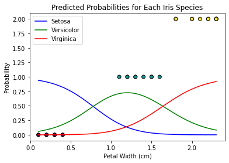

```python
# your code here

#Load Iris dataset (as an example, ensure you have your actual data)
iris = datasets.load_iris()
X = iris.data[:, 3:]  # assuming petal width is the fourth feature
y = iris.target

#Split
from sklearn.model_selection import train_test_split
X_train, X_test, y_train, y_test = train_test_split(X, y, test_size=0.2, random_state=42)

#multinomial logistic regression model
lr_model_multinomial = LogisticRegression(multi_class='multinomial', solver='lbfgs', max_iter=1000)
lr_model_multinomial.fit(X_train, y_train)

#Petal width val
petal_width_values = np.linspace(X_test.min(), X_test.max(), 100).reshape(-1, 1)

probabilities = lr_model_multinomial.predict_proba(petal_width_values)

#Plot the test
plt.scatter(X_test, y_test, c=y_test, cmap='viridis', edgecolors='k')

#Plot predicted proba
plt.plot(petal_width_values, probabilities[:, 0], color='blue', label='Setosa')
plt.plot(petal_width_values, probabilities[:, 1], color='green', label='Versicolor')
plt.plot(petal_width_values, probabilities[:, 2], color='red', label='Virginica')

plt.xlabel('Petal Width (cm)')
plt.ylabel('Probability')
plt.title('Predicted Probabilities for Each Iris Species')
plt.legend()
#plot it all
plt.show()
```

## Multinomial Regression with Two Features

Finally, perform multinomial logistic regression to classify flowers as either Iris Setosa, Iris Versicolor, or Iris Verginica, using only **sepal length and sepal width** as your predictors.

Train the model using the training data, and then make predictions on (what else) the test data.

Save the predictions as variable `yhat`.

Report the overall accuracy of the model (on the test data) as `acc`.

Note that the accuracy of this model will be appreciable less than the model above that used only a single feature. That's because we are using two rather poor predictors, sepal length and sepal width.

```python
# your code here

from sklearn.datasets import load_iris

#Reloading my iris dataset
iris = load_iris()
df = pd.DataFrame(data=iris.data, columns=iris.feature_names)
target = pd.Series(iris.target)

#Now I am using  predictor columns
predictors = ['sepal length (cm)', 'sepal width (cm)']

#Split
X_train, X_test, y_train, y_test = train_test_split(df[predictors], target, test_size=0.5, random_state=1234)

#logistic regression model
lr_model_sl_sw = LogisticRegression(multi_class="multinomial", solver="lbfgs")

#Fittting the model to prevent skewed results
lr_model_sl_sw.fit(X_train, y_train)

#Make pred on test data
yhat = lr_model_sl_sw.predict(X_test)

#Calculate the accuracy of the model
acc = accuracy_score(y_test, yhat)
print(f"Accuracy using sepal length and sepal width as predictors: {acc:.2f}")
```

```
Accuracy using sepal length and sepal width as predictors: 0.81
```

```python
## test whether 2th and 3rd decimal digits of acc are 13
assert np.mod(int(np.floor(acc * 10**3)), 100) == 13
```

```python
## test whether acc is correct (hidden tests)
```

## Decision Surface

Make two plots that plot the decision surface and either (1) the training data, or (2) the testing data. Your plots should resemble the following:

[figure not shown]

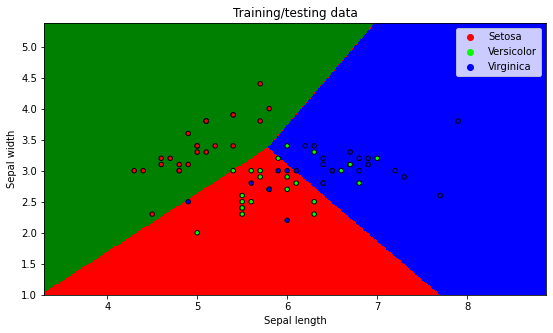

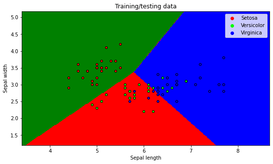

```python
# your code here
# Function to plot decision surface along with data points

#import matplotlib.pyplot as plt
#from matplotlib.colors import ListedColormap

def plot_decision_surface(X, y, model, dataset_type='training'):
    #colormap
    cmap_light = ListedColormap(['green', 'red', 'blue'])
    cmap_bold = ListedColormap(['#FF0000', '#00FF00', '#0000FF'])

    #Create mesh
    h = .02  #step size
    x_min, x_max = X.iloc[:, 0].min() - 1, X.iloc[:, 0].max() + 1
    y_min, y_max = X.iloc[:, 1].min() - 1, X.iloc[:, 1].max() + 1
    xx, yy = np.meshgrid(np.arange(x_min, x_max, h),
                         np.arange(y_min, y_max, h))

    #Predict function value of gid
    Z = model.predict(np.c_[xx.ravel(), yy.ravel()])
    Z = Z.reshape(xx.shape)

    #Plot in general
    plt.figure(figsize=(9, 5))
    plt.contourf(xx, yy, Z, cmap=cmap_light)

    #Plot training points
    scatter = plt.scatter(X.iloc[:, 0], X.iloc[:, 1], c=y, cmap=cmap_bold, edgecolor='k', s=20)
    plt.xlim(xx.min(), xx.max())
    plt.ylim(yy.min(), yy.max())
    plt.title(f"Training/testing data")
    plt.xlabel('Sepal length')
    plt.ylabel('Sepal width')
    plt.legend(handles=scatter.legend_elements()[0], labels=['Setosa', 'Versicolor', 'Virginica'])

#train
plot_decision_surface(X_train_sl_sw, y_train, lr_model_sl_sw, 'training')

#test
plot_decision_surface(X_test_sl_sw, y_test, lr_model_sl_sw, 'testing')
```